# MonteCarlo 17

8 actividades triangulares; límite 3 operarios, plazo 19

# Enunciado

Considere el proyecto cuyo cuadro de prelaciones, duración de cada actividad (mínima *a*, más probable *m* y máxima *b*, en semanas, distribución triangular) y operarios necesarios se adjunta. Cada actividad necesita un número fijo de operarios durante toda su duración y la empresa dispone como máximo de 3 operarios por semana. El contrato exige terminar en **19 semanas**.

1. Calcule con las duraciones más probables la duración del proyecto sin límite de recursos y con el límite de operarios (algoritmo de asignación).

2. Simule 2000 réplicas: en cada una sortee las duraciones, calcule la duración sin recursos y **replanifique** con el límite. Compare media, desviación típica y percentil 90 de ambas distribuciones.

3. Estime la probabilidad de cumplir el plazo de 19 semanas ignorando los recursos y respetándolos. ¿Qué conclusión sacaría un director que solo mirase el camino crítico?

4. Calcule el índice de criticidad de cada actividad sin y con recursos, y la frecuencia con que el límite de operarios retrasa alguna actividad. ¿Qué actividades pasan a mandar al introducir el límite?

5. ¿Cómo cambia la probabilidad de cumplir si se amplía el límite en un operario? Decida si merece la pena.

Tabla 1: Cuadro de datos del enunciado

| activity | predecessor | a | m | b | operarios |
| --- | --- | --- | --- | --- | --- |
| A | --- | 1 | 2 | 3 | 3 |
| B | --- | 6 | 7 | 8 | 1 |
| C | --- | 5 | 6 | 8 | 2 |
| D | A,B,C | 4 | 5 | 7 | 2 |
| E | A,B | 2 | 3 | 6 | 3 |
| F | E | 2 | 4 | 7 | 1 |
| G | D,E | 1 | 2 | 4 | 1 |
| H | F,G | 1 | 2 | 3 | 1 |

El proyecto corresponde a la apertura de una clínica veterinaria; las actividades son las siguientes (las duraciones del cuadro están en semanas).

Tabla 2: Descripción de las actividades

|  | Descripción |
| --- | --- |
| A | Estudio de mercado y local |
| B | Proyecto de reforma y licencia |
| C | Obra de reforma |
| D | Instalación de quirófano y radiología |
| E | Mobiliario y equipamiento clínico |
| F | Software de gestión |
| G | Selección de personal |
| H | Acuerdos con proveedores |

# Resolución

## Apartado 1

1. Calcule con las duraciones más probables la duración del proyecto sin límite de recursos y con el límite de operarios (algoritmo de asignación).

Cálculo de los tiempos mínimos y máximos de los nodos del grafo Roy paso a paso. El primer paso muestra el grafo resuelto; a partir del siguiente se calcula desde el principio (avance con los botones):

paso 0 de 22

[figure not shown]

Figura 1: Grafo Roy con las duraciones más probables y el camino crítico (sin límite)

Tabla 3: Calendario sin límite de recursos

[figure not shown]

Haz clic en un número de la tabla para ver cómo se calcula.

👆 **Interactivo:** haz clic en cualquier celda de la tabla para ver cómo se calcula (otro clic la deselecciona).

| Actividad | Duración | Inicio más temprano | Fin más temprano | Inicio más tardío | Fin más tardío | H total | H libre | H independiente |
| --- | --- | --- | --- | --- | --- | --- | --- | --- |
| A | 2 | 0 | 2 | 5 | 7 | 5 | 5 | 5 |
| B | 7 | 0 | 7 | 0 | 7 | 0 | 0 | 0 |
| C | 6 | 0 | 6 | 1 | 7 | 1 | 1 | 1 |
| D | 5 | 7 | 12 | 7 | 12 | 0 | 0 | 0 |
| E | 3 | 7 | 10 | 7 | 10 | 0 | 0 | 0 |
| F | 4 | 10 | 14 | 10 | 14 | 0 | 0 | 0 |
| G | 2 | 12 | 14 | 12 | 14 | 0 | 0 | 0 |
| H | 2 | 14 | 16 | 14 | 16 | 0 | 0 | 0 |

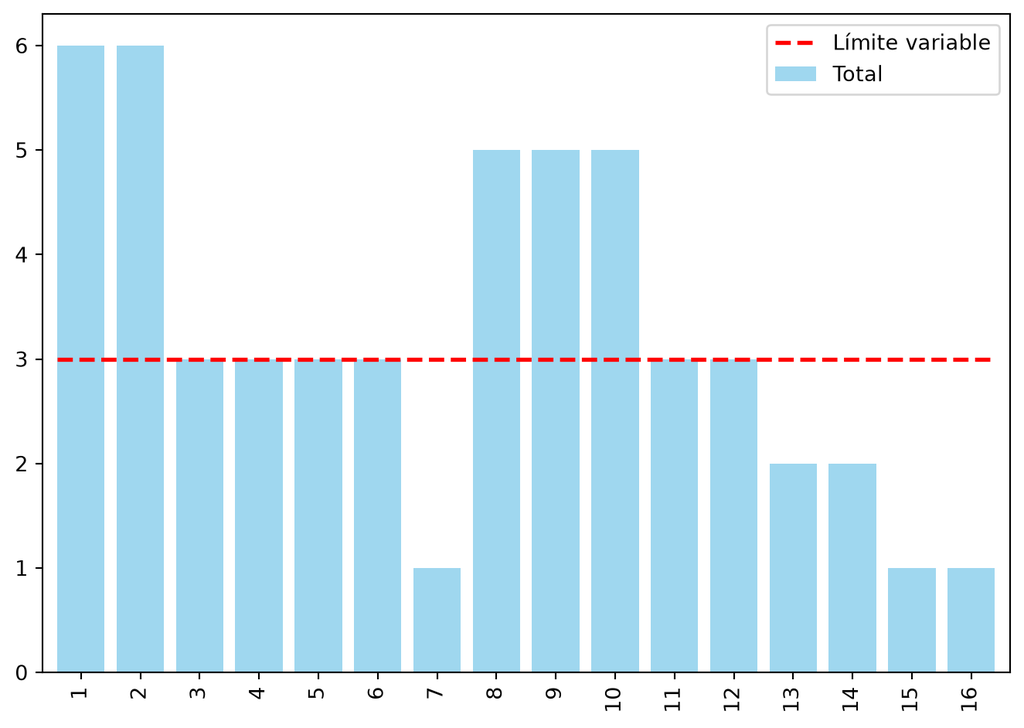

Figura 2: Carga de operarios con los inicios más tempranos frente al límite

El algoritmo de asignación recorre las semanas: cada actividad disponible (predecesoras terminadas) empieza, por orden de prioridad (menor inicio más tardío), si caben sus operarios durante toda su duración; si no, espera. Traza semana a semana y Gantt resultante (filas 💤: esperas):

Periodo 1. Empiezan: [‘B’, ‘C’]. Esperan: [‘A (operarios)’]

Periodo 2. Empiezan: []. Esperan: [‘A (operarios)’]

Periodo 3. Empiezan: []. Esperan: [‘A (operarios)’]

Periodo 4. Empiezan: []. Esperan: [‘A (operarios)’]

Periodo 5. Empiezan: []. Esperan: [‘A (operarios)’]

Periodo 6. Empiezan: []. Esperan: [‘A (operarios)’]

Periodo 7. Empiezan: []. Esperan: [‘A (operarios)’]

Periodo 8. Empiezan: [‘A’]. Esperan: []

Periodo 10. Empiezan: [‘E’]. Esperan: [‘D (operarios)’]

Periodo 11. Empiezan: []. Esperan: [‘D (operarios)’]

Periodo 12. Empiezan: []. Esperan: [‘D (operarios)’]

Periodo 13. Empiezan: [‘D’, ‘F’]. Esperan: []

Periodo 18. Empiezan: [‘G’]. Esperan: []

Periodo 20. Empiezan: [‘H’]. Esperan: []

[figure not shown]

Figura 3: Gantt con el límite de operarios y las duraciones más probables

Tabla 4: Inicio de cada actividad sin y con límite

|  | A | B | C | D | E | F | G | H |
| --- | --- | --- | --- | --- | --- | --- | --- | --- |
| inicio sin límite | 0 | 0 | 0 | 7 | 7 | 10 | 12 | 14 |
| inicio con límite | 7 | 0 | 0 | 12 | 9 | 12 | 17 | 19 |
| fin con límite | 9 | 7 | 6 | 17 | 12 | 16 | 19 | 21 |
| espera (semanas) | 7 | 0 | 0 | 3 | 0 | 0 | 0 | 0 |

Con las duraciones más probables: 16 semanas sin límite y 21 semanas con 3 operarios.

## Apartado 2

2. Simule 2000 réplicas: en cada una sortee las duraciones, calcule la duración sin recursos y **replanifique** con el límite. Compare media, desviación típica y percentil 90 de ambas distribuciones.

En cada réplica se sortean las duraciones (triangulares, redondeadas a semanas enteras), se calcula la duración sin recursos (camino más largo) y se vuelve a aplicar el algoritmo de asignación con el límite: dos duraciones por réplica. `monte_carlo_recursos` hace las 2000 réplicas y guarda ambas.

Tabla 5: Distribución de la duración con y sin límite de recursos

|  | media | desv. típica | q05 | q50 | q95 |
| --- | --- | --- | --- | --- | --- |
| sin recursos | 17.55 | 1.28 | 16.0 | 17.0 | 20.0 |
| con recursos | 22.68 | 1.69 | 20.0 | 23.0 | 25.0 |
| retraso por recursos | 5.13 | 1.34 | 3.0 | 5.0 | 7.0 |

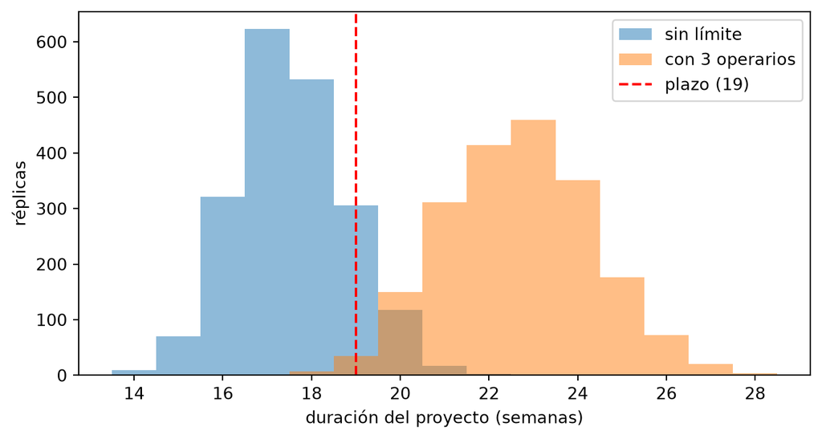

Figura 4: Distribución simulada de la duración sin y con el límite de operarios

La media sube de 17.55 a 22.68 semanas y la desviación típica pasa de 1.28 a 1.69. El límite añade esperas que dependen de qué actividades coinciden en cada réplica.

## Apartado 3

3. Estime la probabilidad de cumplir el plazo de 19 semanas ignorando los recursos y respetándolos. ¿Qué conclusión sacaría un director que solo mirase el camino crítico?

P(T ≤ 19) = 0.930 sin recursos y 0.021 con el límite de operarios. Quien solo mirase el camino crítico creería que el plazo es seguro cuando en realidad el riesgo real es mucho mayor.

## Apartado 4

4. Calcule el índice de criticidad de cada actividad sin y con recursos, y la frecuencia con que el límite de operarios retrasa alguna actividad. ¿Qué actividades pasan a mandar al introducir el límite?

Tabla 6: Criticidad sin y con recursos

|  | sin recursos | con recursos |
| --- | --- | --- |
| A | 0.0 | 100.0 |
| E | 66.6 | 100.0 |
| H | 100.0 | 100.0 |
| D | 55.6 | 99.5 |
| B | 95.4 | 92.0 |
| G | 55.8 | 77.8 |
| C | 23.4 | 39.9 |
| F | 66.4 | 33.2 |

Tabla 7: Frecuencia con que cada recurso bloquea alguna actividad

|  | % de réplicas |
| --- | --- |
| operarios | 100.0 |

La criticidad con recursos incluye actividades que no son críticas en el CPM pero forman parte de la cadena de esperas por el recurso: pasan a mandar al introducir el límite.

## Apartado 5

5. ¿Cómo cambia la probabilidad de cumplir si se amplía el límite en un operario? Decida si merece la pena.

Con 4 operarios P(T ≤ 19) pasa de 0.021 a 0.076; la media baja de 22.68 a 21.96 semanas. Merece la pena si el valor de asegurar el plazo (penalizaciones evitadas × probabilidad ganada) supera el coste del operario adicional.